# Generating publication-ready sequence logos in R using ggseqlogo

# Citation

If you use ggseqlogo please cite:

Wagih, Omar. ggseqlogo: a versatile R package for drawing sequence logos. *Bioinformatics* (2017). https://doi.org/10.1093/bioinformatics/btx469

# Installation

First, install `ggseqlogo` from CRAN

```r
install.packages("ggseqlogo")
```

or from github using the `devtools` package:

```r
devtools::install_github("omarwagih/ggseqlogo")
```

# Getting started

## Load sample data

To get started, fire up the packages and load some sample data.

```r
# Load the required packages
require(ggplot2)
require(ggseqlogo)

# Some sample data
data(ggseqlogo_sample)
```

This loads three sample data sets:

- `seqs_dna`: sets of binding sites for 12 transcription factors obtained from FASTA files in [JASPAR](http://jaspar.genereg.net/). This is represented as a named list of character vectors, where the names represent the JASPAR ID.
- `pfms_dna`: a list of position frequency matrices for four transcription factors obtained from [JASPAR](http://jaspar.genereg.net/). This is represented as a list of matrices, where the names represent the JASPAR ID.
- `seqs_aa`: sets of kinase-substrate phosphorylation sites obtained from [Wagih et al.](https://www.ncbi.nlm.nih.gov/pubmed/25938373) This is represented as a named list of character vectors where the names represent the names of the kinases associated with the phosphosites.

## Plot a sequence logo

You can draw a sequence logos using `ggplot` function, with `geom_logo`. Let’s try this on sequences for one of the transcription factors from JASPAR:

```r
ggplot() + geom_logo( seqs_dna$MA0001.1 ) + theme_logo()
```

You can also use the `ggseqlogo` as a shortcut to do the same thing. This is a wrapper function which adds `theme_logo` by default and performs any required faceting if multiple sequences logos are to be drawn. This is the function used throughout this tutorial.

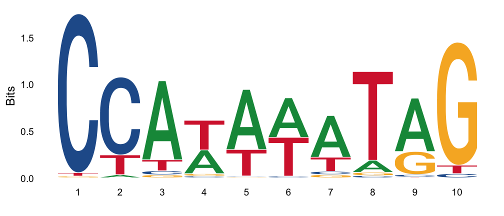

Using the ggseqlogo wrapper function as a shortcut

```r
ggseqlogo( seqs_dna$MA0001.1 )
```

# Accepted input formats

1. Sequences: a character vector of aligned sequences
2. Matrices: a position frequency matrix, where the row is the letter, and column is the position. Note: the matrix must be row named with the letter. Matrices can also be a custom height matrix, but this is described later in the tutorial

The following generates a sequence logo using a position frequency matrix from the sample data

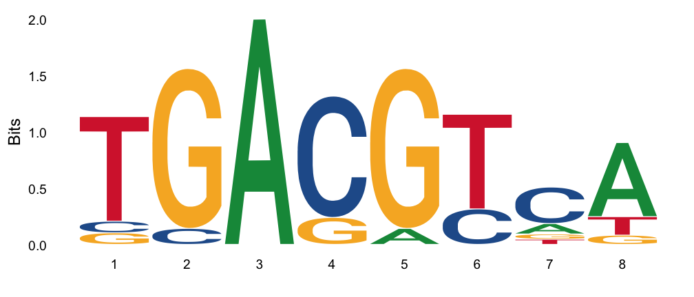

Creating sequence logos using position frequency matrices

```r
ggseqlogo( pfms_dna$MA0018.2 )
```

# Plotting methods

ggseqlogo supports two sequence logo methods through the `method` options: ‘bits’ and ‘probability’. By default, the bits is used.

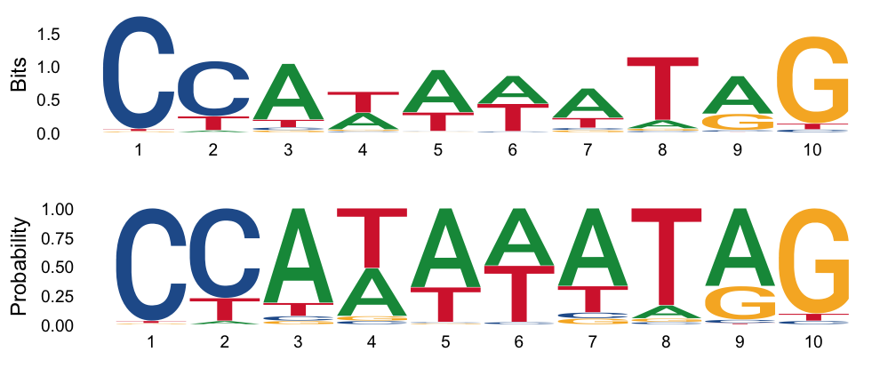

Using different methods to plot a sequence logo

```r
p1 = ggseqlogo( seqs_dna$MA0001.1, method = 'bits' )
p2 = ggseqlogo( seqs_dna$MA0001.1, method = 'prob' )
gridExtra::grid.arrange(p1, p2)
```

# Sequence types

## Preset alphabets

Amino acids, DNA and RNA sequence types are all supported by ggseqlogo. By default, ggseqlogo will try to guess your sequence type. You can explicitly set the sequence type through the `seq_type` option.

Lets try generate an amino acid sequence logo using kinase-substrate phosphorylation data:

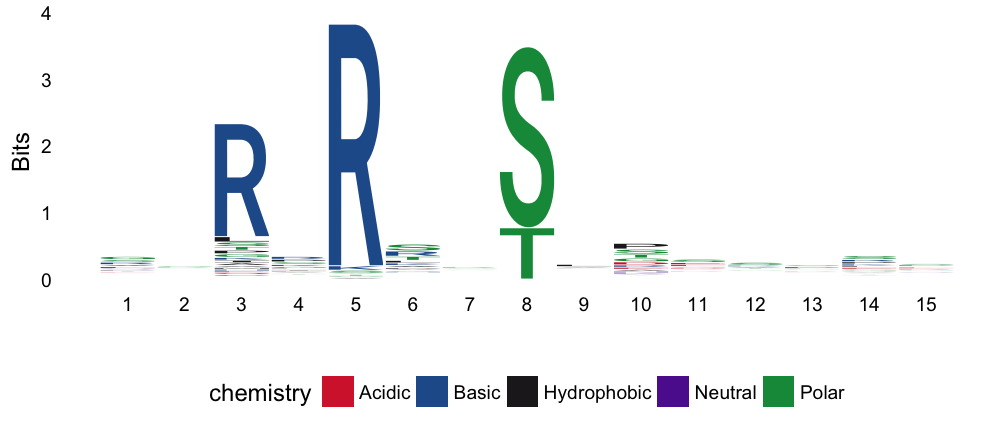

An example sequence logo for amino acids

```r
ggseqlogo( seqs_aa$AKT1, seq_type='aa' )
```

## Custom alphabet

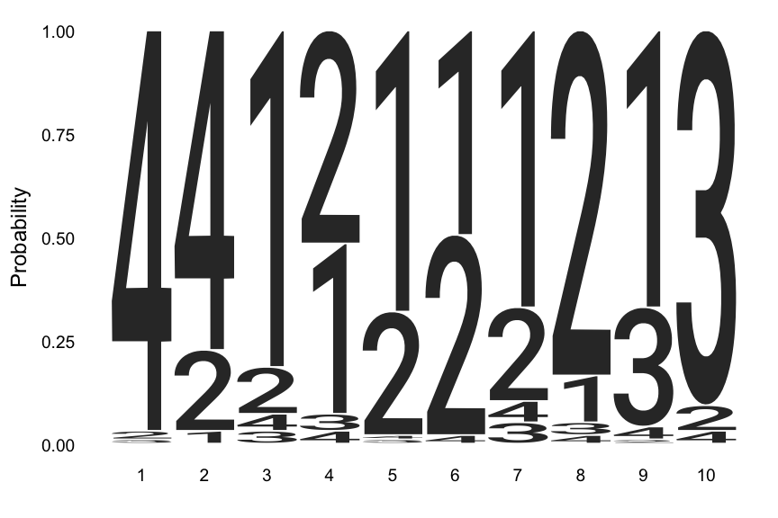

Generating sequence logos with custom dictionaries - numerical characters

```r
# Replace DNA characters with numbers
seqs_numeric = chartr('ATGC','1234', seqs_dna$MA0001.1)
ggseqlogo(seqs_numeric, method='p', namespace=1:4)
```

Greek letters are also supported:

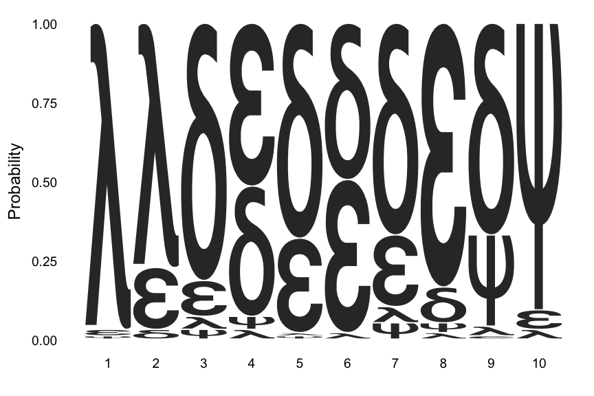

Generating sequence logos with custom dictionaries - Greek characters

```r
# Replace DNA characters with Greek ones
seqs_greek = chartr('ATGC', 'δεψλ', seqs_dna$MA0001.1)
ggseqlogo(seqs_greek, namespace='δεψλ', method='p')
```

For colors, you will need to create a custom color scheme for your namespace.

# Colour schemes

## Preset colour schemes

ggseqlogo has preset colour schemes that can be set using the `col_scheme` parameter. By default, the `col_scheme` is set to `auto` such that the colour scheme is automatically chosen based on your sequence type.

You can adjust the parameter. For amino acids you can pick from the following `chemistry`, `hydrophobicity`, `clustalx`, `taylor`. For DNA and RNA sequences `nucleotide` and `base_pairing`. For a full list of color schemes, see the `list_col_schemes` function. For example:

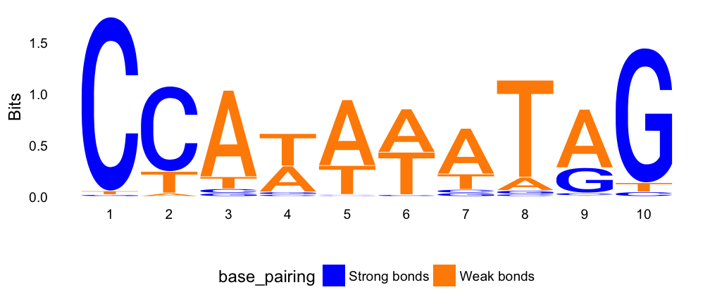

An example of using a preset colour scheme

```r
ggseqlogo(seqs_dna$MA0001.1, col_scheme='base_pairing')
```

## Custom colour schemes

If the presets are not enough for you, you can define custom discrete or continuous colour schemes using the `make_col_scheme` function. Here are two examples of discrete and continuous colour schemes.

### Discrete color schemes

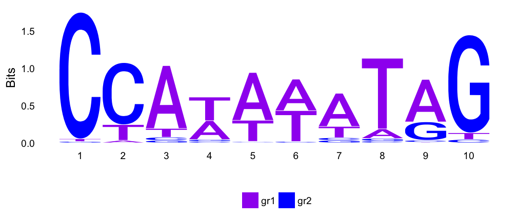

An example of a custom discrete colour scheme

```r
# Create custom colour scheme
cs1 = make_col_scheme(chars=c('A', 'T', 'C', 'G'), groups=c('gr1', 'gr1', 'gr2', 'gr2'),
                      cols=c('purple', 'purple', 'blue', 'blue'))

# Generate sequence logo
ggseqlogo(seqs_dna$MA0001.1, col_scheme=cs1)
```

Note that the `groups` parameter here is optional

### Continuous color schemes

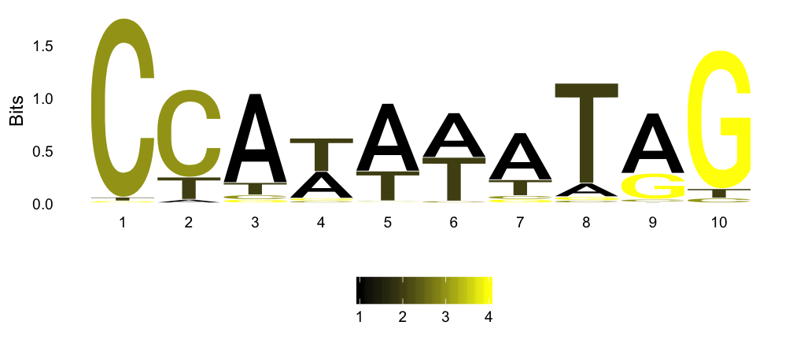

An example of a custom continuous colour scheme

```r
# Create custom colour scheme
cs2 = make_col_scheme(chars=c('A', 'T', 'C', 'G'), values=1:4)

# Generate sequence logo
ggseqlogo(seqs_dna$MA0001.1, col_scheme=cs2)
```

# Multiple sequence logos

You can plot more than one sequence logo at the same time with the help of facets. `ggseqlogo` will accept a named list of sequences or matrices. The names of the list will be used as the facet titles.

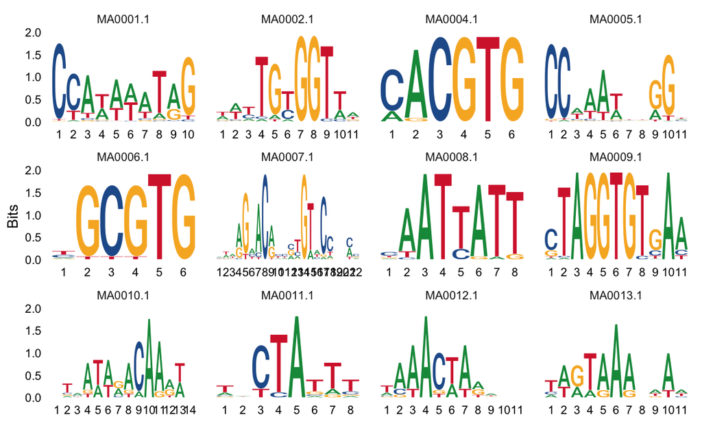

Generating multiple sequence logos at once using a list as an input

```r
ggseqlogo(seqs_dna, ncol=4)
```

which is the same as calling:

```r
ggplot() + geom_logo(seqs_dna) + theme_logo() +
  facet_wrap(~seq_group, ncol=4, scales='free_x')
```

# Custom-height logos

If you have your own height metric for each letter, simply create a matrix where each cell is a the desired height, and set the `method` to custom. You can even have negative heights. Here’s a simple example:

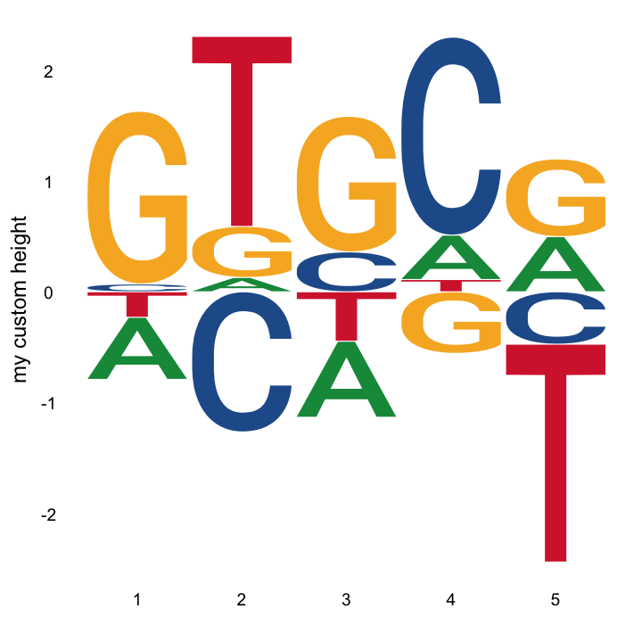

Using custom heights

```r
# Create a custom matrix
set.seed(123)
custom_mat = matrix( rnorm(20), nrow=4, dimnames=list(c('A', 'T', 'G', 'C')))

# Generate sequence logo
ggseqlogo(custom_mat, method='custom', seq_type='dna') + ylab('my custom height')
```

# Fonts

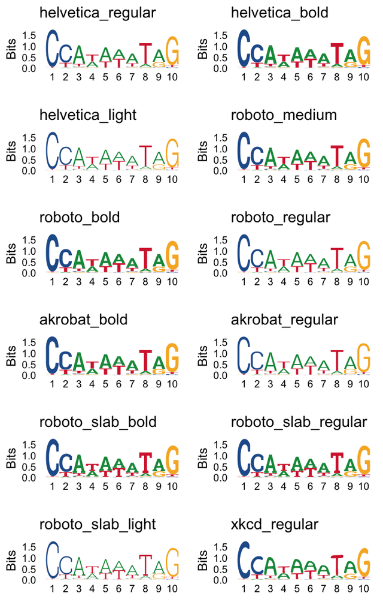

Using different fonts with ggseqlogo

```r
fonts = list_fonts(F)

p_list = lapply(fonts, function(f){
  ggseqlogo(seqs_dna$MA0001.1, font=f) + ggtitle(f)
})

do.call(gridExtra::grid.arrange, c(p_list, ncol=2))
```

# Annotating logos

Overlaying annotation onto sequence logos is straightforward in ggseqlogo with ggplot2. Here is an example of drawing rectangles, lines and text.

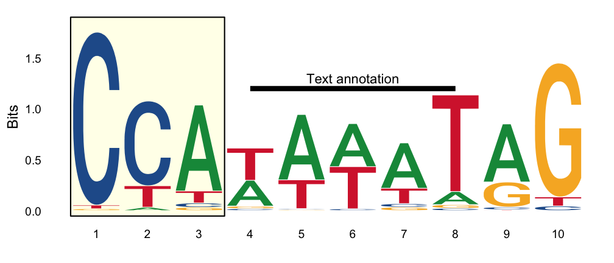

Annotating sequence logos

```r
ggplot() +
  annotate('rect', xmin = 0.5, xmax = 3.5, ymin = -0.05, ymax = 1.9, alpha = .1, col='black', fill='yellow') +
  geom_logo(seqs_dna$MA0001.1, stack_width = 0.90) +
  annotate('segment', x = 4, xend=8, y=1.2, yend=1.2, size=2) +
  annotate('text', x=6, y=1.3, label='Text annotation') +
  theme_logo()
```

# Combining plots

Combining sequence logos with other plots generated by ggplot2 is simple. I’ll demonstrate with an example combining a sequence logo, sequence alignment and bar plot.

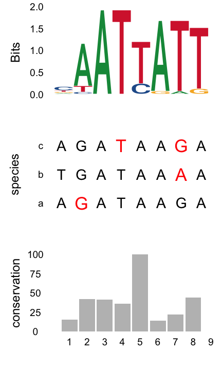

Combining sequence logos with other ggplot2 plots

```r
# Sequences we're going to use for the logo
seqs = seqs_dna$MA0008.1

# Generate the sequence logo
p1 = ggseqlogo(seqs) + theme(axis.text.x = element_blank())

# Make data for sequence alignment
aln = data.frame(
  letter=strsplit("AGATAAGATGATAAAAAGATAAGA", "")[[1]],
  species = rep(c("a", "b", "c"), each=8),
  x       = rep(1:8, 3)
)
aln$mut = 'no'
aln$mut[ c(2,15,20,23) ] = 'yes'

# Generate the sequence alignment
p2 = ggplot(aln, aes(x, species)) +
  geom_text(aes(label=letter, color=mut, size=mut)) +
  scale_x_continuous(breaks=1:10, expand = c(0.105, 0)) + xlab('') +
  scale_color_manual(values=c('black', 'red')) +
  scale_size_manual(values=c(5, 6)) +
  theme_logo() +
  theme(legend.position = 'none', axis.text.x = element_blank())

# Generate barplot data
bp_data = data.frame(x=1:8, conservation=sample(1:100, 8))

# Generate barplot data
p3 = ggplot(bp_data, aes(x, conservation)) +
  geom_bar(stat='identity', fill='grey') +
  theme_logo() +
  scale_x_continuous(breaks=1:10, expand = c(0.105, 0)) +
  xlab('')


# Now combine using cowplot, which ensures the plots are aligned
suppressMessages( require(cowplot) )
plot_grid(p1, p2, p3,  ncol = 1, align = 'v')
```

# Documentation

For more details on all features and parameters see `?ggseqlogo`, `?geom_logo` and `?make_col_scheme`

# Feedback

If you have any feedback or suggestions, please drop me a line at (omarwagih(at)gmail.com) or open an issue on Github.